# Curso de introducción a la programación con Python

**Autor: Luis Fernando Apáez Álvarez**

## Proyecto 2 (parte I): Creando la clase `graficar`

En este proyecto comenzaremos creando una clase denominada `graficar`, con la cual conseguiremos graficar funciones. Para lograrlo nos valdremos del código ya creado en el anterior proyecto, más especificamente en `Proyecto 1 (parte I): Graficador de funciones`. Nuestra labor será adaptar dicho código a una clase. Para ello

- Comenzaremos por crear un menú que nos auxilie a saber el tipo de función que ingresará el usuario. Después pediremos a dicho usuario que ingrese su función

```python
# Importamos las librerías que más adelante ocuparemos
import matplotlib.pyplot as mplot
import numpy as np

# Menú:

print("De que tipo es tu función: ")
print("_" * 30)
print("1: Algebraicas")
print("2: Trigonométricas")
print("3: Exponencial")
print("4: Logarítmica")
print("_" * 30)

# Número del tipo de función que ingresa el usuario
n_aux = input("Coloca un número del 1 al 4: ")
print("_" * 30)

# Controlamos posibles errores
if int(n_aux) not in (1,2,3,4):
    print("Error, debes ingresar un número del 1 al 4")
    print("Fin del proceso")
else:
    # Función ingresada por el usuario
    fun = input("Ingresa tu función: ")

# -------------------------------------------------
```

```
De que tipo es tu función:
______________________________
1: Algebraicas
2: Trigonométricas
3: Exponencial
4: Logarítmica
______________________________
Coloca un número del 1 al 4: 1
______________________________
Ingresa tu función: x**2
```

Agregamos un condicional para manejar las funciones trigonométricas, exponenciales y logarítmicas mediante la librería `numpy`

```python
if int(n_aux) != 1:
    fun = "np." + fun
else:
    fun = fun
```

- Creamos la clase `graficar` colocando en el constructor los atributos necesarios para que el usuario ingrese un intervalo de graficación (que denominaremos rango) y la función en sí a graficar. Asimismo, crearemos la clase `str` para mostrar el rango de graficación de dicha función y la expresión de dicha función.

```python
# Creación de la clase graficar
class graficar:
    # Constructor
    def __init__(self, rango, funcion):

        # Atributos de la clase
        self.rango_inf = rango[0]
        self.rango_sup = rango[1]
        self.funcion = funcion

    # Método str
    def __str__(self):
        return f'Rango:({self.rango_inf},{self.rango_sup})\nf(x) = {self.funcion}'
```

cabe resaltar que supondremos que el parámetro de `rango` será o una tupla o una lista. Probemos lo que llevamos:

```python
# Instanciamos la clase
prueba = graficar((-1,1), fun)

# Utilizamos el método str
print(prueba)
```

```
Rango:(-1,1)
f(x) = x**2
```

- Finalmente, dentro de la clase `graficar` agregaremos el método `Graficador()` para que se grafique la función que el usuario ha ingresado:

```python
# Creación de la clase graficar
class graficar:
    # Constructor
    def __init__(self, rango, funcion):

        # Atributos de la clase
        self.rango_inf = rango[0]
        self.rango_sup = rango[1]
        self.funcion = funcion

    # Método str
    def __str__(self):
        return f'Rango:({self.rango_inf},{self.rango_sup})\nf(x) = {self.funcion}'

    # Método para graficar
    def Graficador(self):

        # Rango
        x = np.arange(self.rango_inf, self.rango_sup, 0.01)

        # definimos la función f(x)=y
        y = self.funcion

        # creamos la gráfica
        mplot.plot(x, eval(y))

        # mostramos la cuadrícula en el gráfico
        mplot.grid()

        # mostramos la gráfica
        mplot.show()
```

Ponemos a prueba la clase creada:

```
Rango:(-1,1)
f(x) = x**2
```

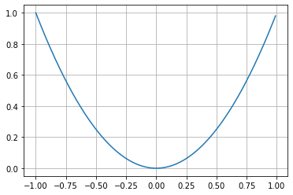

```python
# Instanciamos la clase
prueba = graficar((-1,1), fun)

# Utilizamos el método str
print(prueba)

# Invocamos el método Graficador()
prueba.Graficador()
```

De modo que, por el momento, la clase `graficar` ha quedado terminada.

- Si bien la configuración del menú ya ha quedado, para los fines del proyecto adaptaremos el código que escribimos para convertirlo en una clase

```python
# Creamos la clase menú

class menu:

    # Creamos el método str para mostrar el mensaje inicial
    def __str__(self):
        self.cadena1 = "De que tipo es tu función:"
        self.cadena2 = "_" * 30
        self.cadena3 = "1: Algebraicas"
        self.cadena4 = "2: Trigonométricas"
        self.cadena5 = "3: Exponencial"
        self.cadena6 = "4: Logarítmica"
        self.cadena7 = "_" * 30
        return self.cadena1 + "\n" + self.cadena2 + "\n" + self.cadena3 \
    + "\n" + self.cadena4 + "\n" + self.cadena5 + "\n" + self.cadena6 \
    + "\n" + self.cadena7
```

```python
# Realizamos una prueba

prueba = menu()
print(prueba)
```

```
De que tipo es tu función:
______________________________
1: Algebraicas
2: Trigonométricas
3: Exponencial
4: Logarítmica
______________________________
```

adaptamos el resto del código a un método de la clase `menu`:

```python
# Creamos la clase menú

class menu:

    # Constructor
    def __init__(self):
        self.fun = ""

    # Creamos el método str para mostrar el mensaje inicial
    def __str__(self):
        self.cadena1 = "De que tipo es tu función:"
        self.cadena2 = "_" * 30
        self.cadena3 = "1: Algebraicas"
        self.cadena4 = "2: Trigonométricas"
        self.cadena5 = "3: Exponencial"
        self.cadena6 = "4: Logarítmica"
        self.cadena7 = "_" * 30
        return self.cadena1 + "\n" + self.cadena2 + "\n" + self.cadena3 \
    + "\n" + self.cadena4 + "\n" + self.cadena5 + "\n" + self.cadena6 \
    + "\n" + self.cadena7

    def info_usuario(self):
        # Número del tipo de función que ingresa el usuario
        self.n_aux = input("Coloca un número del 1 al 4: ")
        print("_" * 30)

        # Controlamos posibles errores
        if int(self.n_aux) not in (1,2,3,4):
            print("Error, debes ingresar un número del 1 al 4")
            print("Fin del proceso")
        else:
            # Función ingresada por el usuario
            self.fun = input("Ingresa tu función: ")

        # Adaptamos
        if int(self.n_aux) != 1:
            self.fun = "np." + self.fun
        else:
            self.fun = self.fun
```

Nos vimos en la necesidad de crear un constructor para almacenar un valor para el atributo `self.fun` al cual le asignaremos la expresión de la función que ingrese el usuario más adelante con el método `info_usuario`.

```python
# Probamos

prueba = menu()
print(prueba)

# Invocamos el método info_usuario()
prueba.info_usuario()
```

```
De que tipo es tu función:
______________________________
1: Algebraicas
2: Trigonométricas
3: Exponencial
4: Logarítmica
______________________________
Coloca un número del 1 al 4: 1
______________________________
Ingresa tu función: x**2
```

Veamos que expresión tiene asignado el objeto `prueba` en el atributo `fun`

```python
prueba.fun
```

```
'x**2'
```

De modo que la clase `menú` ah quedado realizada ( por el momento :) ).

- Notemos que, si a la clase `menu` le agregamos como atributo el rango de graficación, entonces esta clase junto con la clase `graficar` tendrán los mismos atributos en el constructor. Además, de la clase `menu` podemos extraer la expresión de la función que ocupamos en la clase `graficar`. Así, podemos intuir que la clase `graficar` en realidad puede ser parte de la clase `menu`, o en otras palabras, la clase `menu` es superclase de la clase `graficar`. De tal manera, tendríamos que agregar solamente el atributo `rango` al constructor de la clase `menu`, pero eso lo podemos ingresar como se ingresa la expresión de la función en el método `info_usuario()`

```python
# Creamos la clase menú

class menu:

    # Constructor
    def __init__(self):
        # Atributos de la clase
        self.fun = ""
        self_rango = ""

    # Creamos el método mensaje_inicial para mostrar el mensaje inicial
    def mensaje_inicial(self):
        self.cadena1 = "De que tipo es tu función:"
        self.cadena2 = "_" * 30
        self.cadena3 = "1: Algebraicas"
        self.cadena4 = "2: Trigonométricas"
        self.cadena5 = "3: Exponencial"
        self.cadena6 = "4: Logarítmica"
        self.cadena7 = "_" * 30
        return self.cadena1 + "\n" + self.cadena2 + "\n" + self.cadena3 \
    + "\n" + self.cadena4 + "\n" + self.cadena5 + "\n" + self.cadena6 \
    + "\n" + self.cadena7

    def info_usuario(self):
        # Número del tipo de función que ingresa el usuario
        self.n_aux = input("Coloca un número del 1 al 4: ")
        print("_" * 30)

        # Controlamos posibles errores
        if int(self.n_aux) not in (1,2,3,4):
            print("Error, debes ingresar un número del 1 al 4")
            print("Fin del proceso")
        else:
            # Función y rango ingresados por el usuario
            self.fun = input("Ingresa tu función: ")

            # Rango
            self.rango = input("Ingresa el rango de graficación: ")
            self.rango_inf = self.rango[self.rango.find("(") + 1: self.rango.find(",")]
            self.rango_sup = self.rango[self.rango.find(",") + 1: self.rango.find(")")]

        # Adaptamos
        if int(self.n_aux) != 1:
            self.fun = "np." + self.fun
        else:
            self.fun = self.fun
```

Para después definir la clase hija `graficar` adaptando los cambios pertinentes. Notemos que `self.rango` será una cadena de texto, de modo que el código para definir las variables `self.rango_inf` y `self.rango_sup` extraen los valores numéricos de dicha cadena de texto; por ejemplo, si se ingresó la cadena `"(0,-4)"`, entonces extraeremos sólo las cadenas `"0"` y `"-4"` para estas variables respectivamente. Continuando

```python
# Creación de la clase hija graficar
class graficar(menu):

    # Sobreescritura del método init
    def __init__(self):
        super().__init__()


    # Método str
    def __str__(self):
        return f'Rango:({self.rango_inf},{self.rango_sup})\nf(x) = {self.fun}'

    # Método para graficar
    def Graficador(self):

        # Rango
        x = np.arange(eval(self.rango_inf), eval(self.rango_sup), 0.01)

        # definimos la función f(x)=y
        y = self.fun

        # creamos la gráfica
        mplot.plot(x, eval(y))

        # mostramos la cuadrícula en el gráfico
        mplot.grid()

        # mostramos la gráfica
        mplot.show()
```

donde con la fucnión `eval()` podemos extraer un número de una cadena de texto; por ejemplo, la cadena `"0"` se transforma en el número `0` al emplear `eval("0")`.

Finalmente probamos cada método de la clase `graficar`:

```python
# instanciamos la clase
prueba = graficar()
```

```python
# Mensaje inicial (proviene de la clase menu)
print(prueba.mensaje_inicial())
```

```
De que tipo es tu función:
______________________________
1: Algebraicas
2: Trigonométricas
3: Exponencial
4: Logarítmica
______________________________
```

```python
# información dle usuario (proviene de la clase menu)
prueba.info_usuario()
```

```
Coloca un número del 1 al 4: 1
______________________________
Ingresa tu función: x**2
Ingresa el rango de graficación: (-1,1)
```

```python
# método str (proviene de la clase graficar)
print(prueba)
```

```
Rango:(-1,1)
f(x) = x**2
```

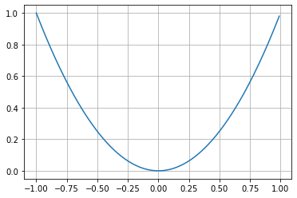

```python
# graficamos (proviene de la clase graficar)
prueba.Graficador()
```